# SUHEYLA_YILDIZ_HW4

## 1.Superconductivity Data Set

**Data Set Information:**

There are two files: (1) train.csv contains 81 features extracted from 21263 superconductors along with the critical temperature in the 82nd column, (2) unique_m.csv contains the chemical formula broken up for all the 21263 superconductors from the train.csv file. The last two columns have the critical temperature and chemical formula. The original data comes from [Web Link] which is public. The goal here is to predict the critical temperature based on the features extracted.

```r
setwd("C:/Users/HP/Desktop/IE582/HW4")
getwd()
```

```
## [1] "C:/Users/HP/Desktop/IE582/HW4"
```

```r
library(data.table)
library(imputeTS)
library(caret)
park_data = data.table(read.csv("train.csv"))
park_data=park_data[ ,lapply(.SD, na_mean)]
park_data=data.frame(data.matrix(park_data))

str(park_data)
```

```
## 'data.frame':    21263 obs. of  82 variables:
##  $ number_of_elements             : num  4 5 4 4 4 4 4 4 4 4 ...
##  $ mean_atomic_mass               : num  88.9 92.7 88.9 88.9 88.9 ...
##  $ wtd_mean_atomic_mass           : num  57.9 58.5 57.9 57.9 57.8 ...
##  $ gmean_atomic_mass              : num  66.4 73.1 66.4 66.4 66.4 ...
##  $ wtd_gmean_atomic_mass          : num  36.1 36.4 36.1 36.1 36.1 ...
##  $ entropy_atomic_mass            : num  1.18 1.45 1.18 1.18 1.18 ...
##  $ wtd_entropy_atomic_mass        : num  1.062 1.058 0.976 1.022 1.129 ...
##  $ range_atomic_mass              : num  123 123 123 123 123 ...
##  $ wtd_range_atomic_mass          : num  31.8 36.2 35.7 33.8 27.8 ...
##  $ std_atomic_mass                : num  52 47.1 52 52 52 ...
##  $ wtd_std_atomic_mass            : num  53.6 54 53.7 53.6 53.6 ...
##  $ mean_fie                       : num  775 766 775 775 775 ...
##  $ wtd_mean_fie                   : num  1010 1011 1011 1011 1010 ...
##  $ gmean_fie                      : num  718 721 718 718 718 ...
```

[output cut: 68 more lines]

```r
response=park_data[,82]
park_data=park_data[,-82]

park_data=cbind(response,park_data)
colnames(park_data)[1]="response"


set.seed(1000)

tr=sample(1:21263, 16666)
park_tr = park_data[tr,]
park_te = park_data[-tr,]
```

## Penalized Regression

Cross validation is used in the penalized regression approach in order to find best value of the lambda.

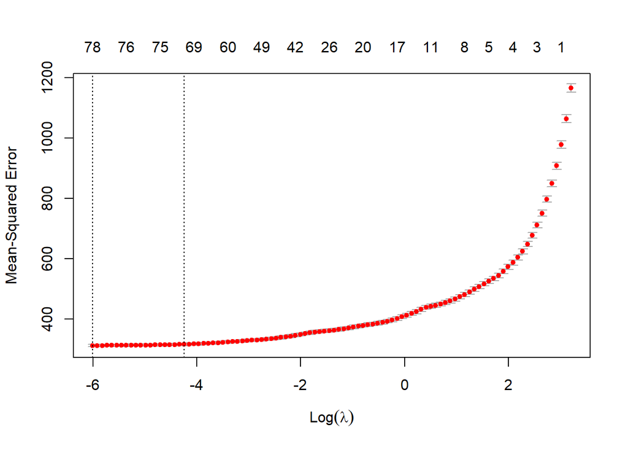

```r
library(glmnet)

park_tr_n = as.matrix(park_tr[,-1])
park_te_n = as.matrix(park_te[,-1])
cross_v = cv.glmnet(park_tr_n,as.matrix(park_tr$response),family="gaussian", alpha=1)
options(repr.plot.width=7, repr.plot.height=7)
plot(cross_v)
```

```r
cross_v
```

```
##
## Call:  cv.glmnet(x = park_tr_n, y = as.matrix(park_tr$response), family = "gaussian",      alpha = 1)
##
## Measure: Mean-Squared Error
##
##       Lambda Index Measure    SE Nonzero
## min 0.002461   100   312.5 3.907      78
## 1se 0.014416    81   316.4 3.946      70
```

```r
print(c("min lambda: ",cross_v$lambda.min))
```

```
## [1] "min lambda: "       "0.0024613120936525"
```

```r
fito= glmnet(park_tr_n,as.matrix(park_tr$response),family="gaussian", alpha=1,lambda=cross_v$lambda.min)
fito
```

```
##
## Call:  glmnet(x = park_tr_n, y = as.matrix(park_tr$response), family = "gaussian",      alpha = 1, lambda = cross_v$lambda.min)
##
##   Df %Dev   Lambda
## 1 77 73.5 0.002461
```

```r
predictions = predict(fito, park_tr_n)

res=cbind(park_tr$response, data.frame(predictions))
rss = sum((res[,2] - res[,1]) ^ 2)
tss =  sum((res[,1] - mean(res[,1])) ^ 2)
rsq = 1 - rss/tss
print(c("coefficient of determination (train):",rsq))
```

```
## [1] "coefficient of determination (train):"
## [2] "0.735037361890729"
```

```r
predictions =  predict(fito, park_te_n)

res=cbind(park_te$response, data.frame(predictions))

for_te = 1 - sum((res[,2] - res[,1]) ^ 2)/sum((res[,1] - mean(res[,1])) ^ 2)
print(c("coefficient of determination (test):",for_te))
```

```
## [1] "coefficient of determination (test):"
## [2] "0.737783394444456"
```

## Decision Tree

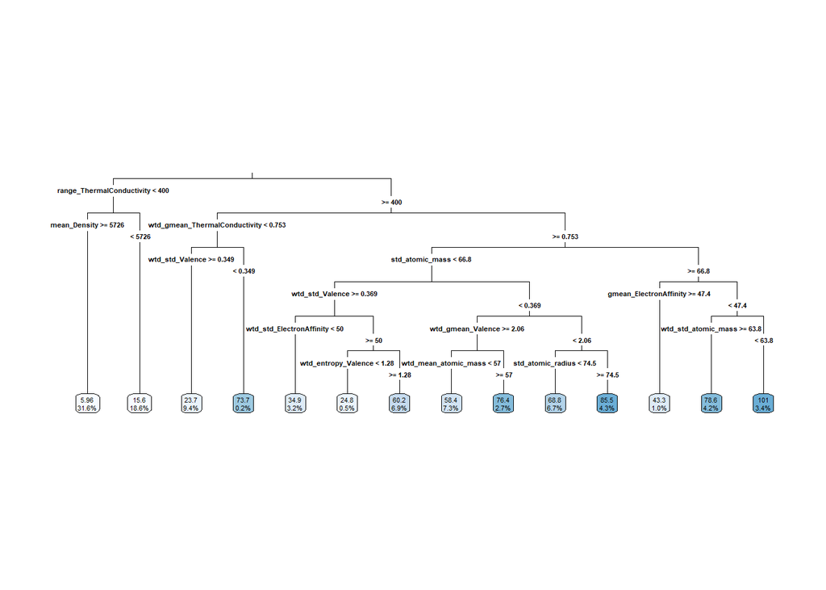

```
## [1] "coefficient of determination:" "0.765979145998821"
```

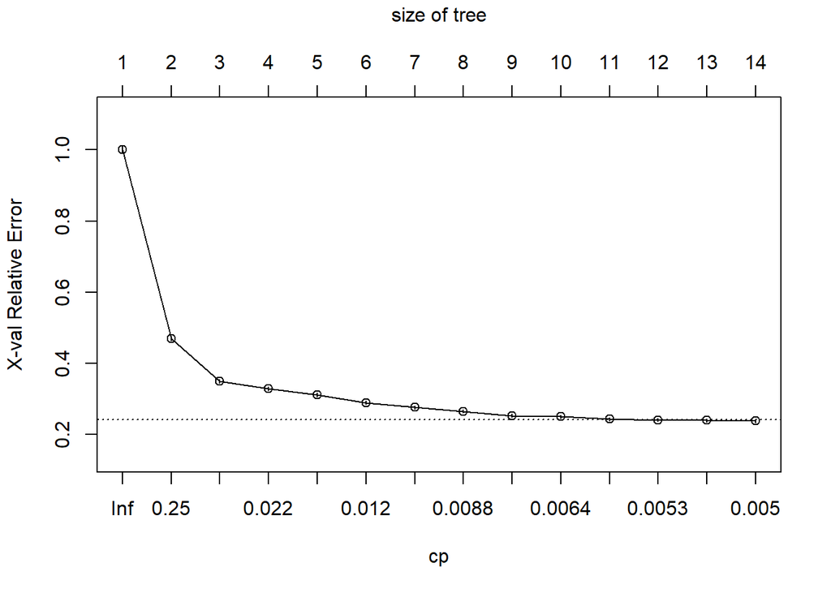

```r
library(rpart)
require(rpart.plot)
set.seed(555)

decision_tree = function(i){
  d_tree=rpart(response~.,data = park_tr,control = rpart.control(minbucket = 2+i,cp=0.005*i),method = "anova")

  rpart.plot(d_tree,type = 3,digits = 3,fallen.leaves = TRUE)

  predictions=predict(d_tree,park_te)
  res=cbind(park_te$response, data.frame(predictions))
  rss =sum((res[,2] - res[,1]) ^ 2)  ## residual sum of squares
  tss = sum((res[,1] - mean(res[,1])) ^ 2)  ## total sum of squares
  rsq = 1 - rss/tss
  print(c("coefficient of determination:",rsq))

  plotcp(d_tree)
  return(rsq)
}

coefficient = list()
c = decision_tree(1)
```

```r
coefficient = append(coefficient,c)

c = decision_tree(2)
```

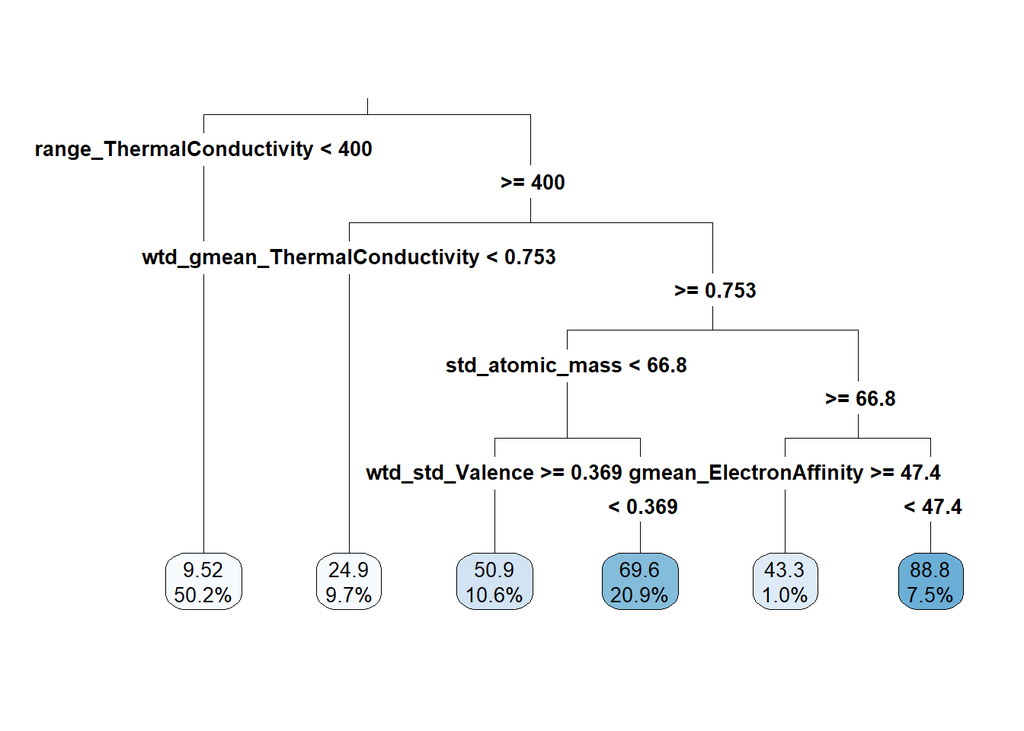

```
## [1] "coefficient of determination:" "0.713422821048078"
```

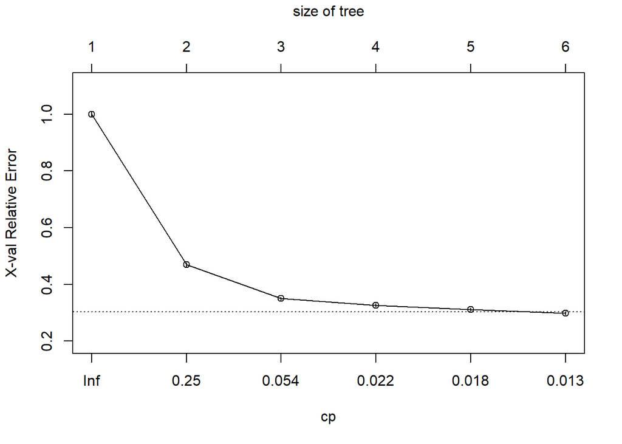

```r
coefficient = append(coefficient,c)

c = decision_tree(3)
```

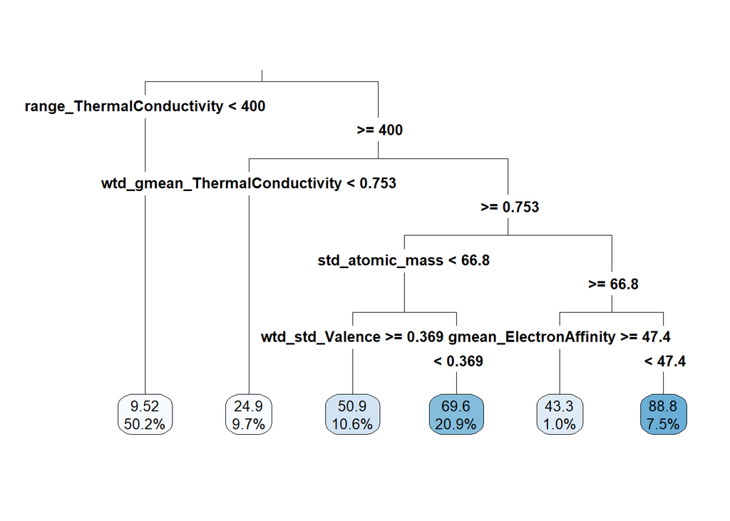

```
## [1] "coefficient of determination:" "0.713422821048078"
```

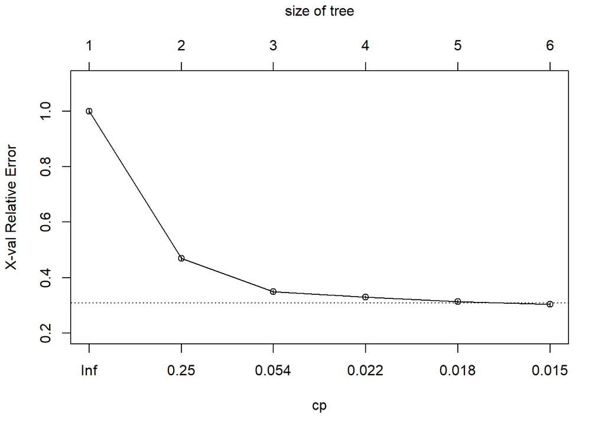

```r
coefficient = append(coefficient,c)

c = decision_tree(4)
```

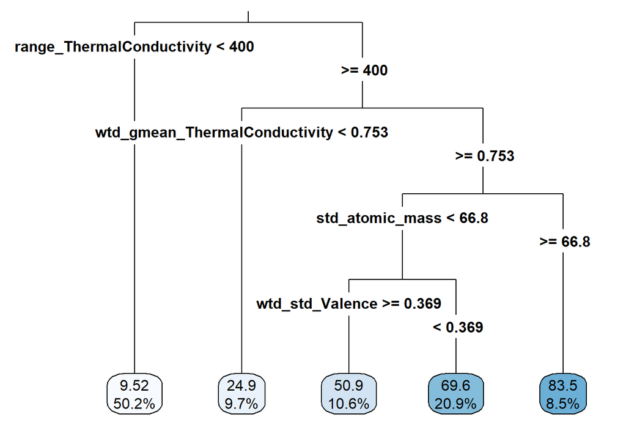

```
## [1] "coefficient of determination:" "0.702605198137848"
```

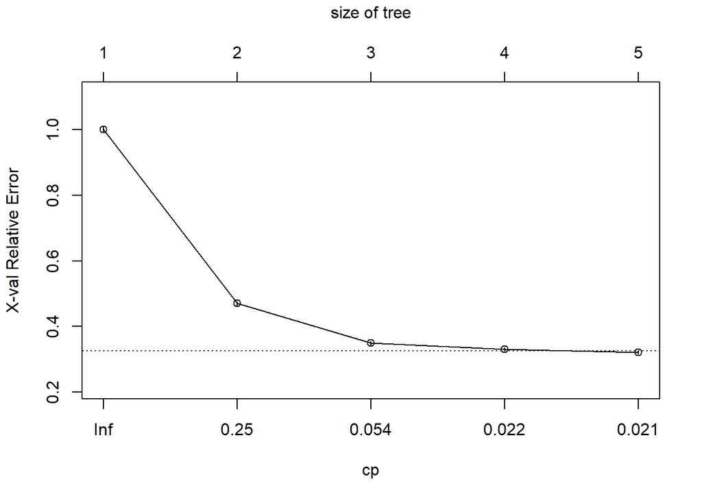

```r
coefficient = append(coefficient,c)

coefficient
```

```
## [[1]]
## [1] 0.7659791
##
## [[2]]
## [1] 0.7134228
##
## [[3]]
## [1] 0.7134228
##
## [[4]]
## [1] 0.7026052
```

## Gradient Boosting

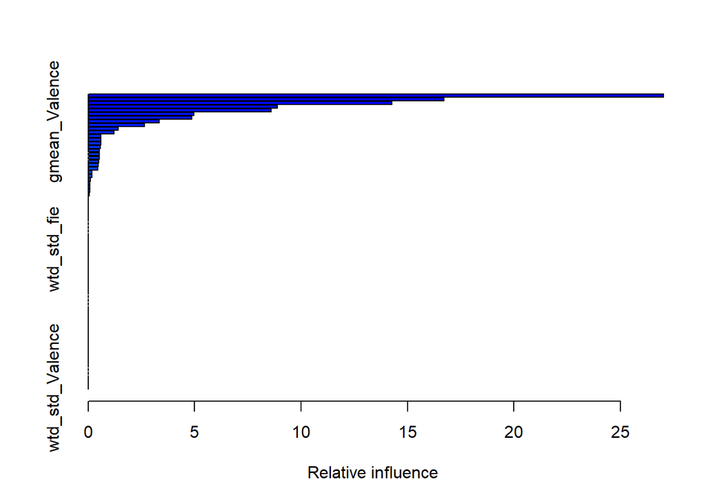

```
##                                                             var     rel.inf
## range_ThermalConductivity             range_ThermalConductivity 27.02393329
## wtd_std_ThermalConductivity         wtd_std_ThermalConductivity 16.69908388
## wtd_entropy_Valence                         wtd_entropy_Valence 14.27681839
## range_atomic_radius                         range_atomic_radius  8.87722571
## wtd_mean_Valence                               wtd_mean_Valence  8.59209311
## wtd_entropy_atomic_mass                 wtd_entropy_atomic_mass  4.97201669
## range_atomic_mass                             range_atomic_mass  4.87027938
## gmean_Valence                                     gmean_Valence  3.32988374
## wtd_gmean_Valence                             wtd_gmean_Valence  2.64383841
## wtd_gmean_ElectronAffinity           wtd_gmean_ElectronAffinity  1.39795573
## wtd_std_atomic_mass                         wtd_std_atomic_mass  1.22204843
## std_atomic_mass                                 std_atomic_mass  0.60349874
## wtd_entropy_ThermalConductivity wtd_entropy_ThermalConductivity  0.60123888
## wtd_gmean_ThermalConductivity     wtd_gmean_ThermalConductivity  0.59705654
## wtd_entropy_FusionHeat                   wtd_entropy_FusionHeat  0.56733573
## mean_ThermalConductivity               mean_ThermalConductivity  0.52721410
## gmean_Density                                     gmean_Density  0.51449520
## wtd_mean_ThermalConductivity       wtd_mean_ThermalConductivity  0.51164271
## gmean_ElectronAffinity                   gmean_ElectronAffinity  0.49817928
## wtd_std_ElectronAffinity               wtd_std_ElectronAffinity  0.46839782
## std_ElectronAffinity                       std_ElectronAffinity  0.44159145
## std_FusionHeat                                   std_FusionHeat  0.18746066
## wtd_mean_Density                               wtd_mean_Density  0.18568830
## std_atomic_radius                             std_atomic_radius  0.09697201
## entropy_Density                                 entropy_Density  0.08857957
## entropy_ElectronAffinity               entropy_ElectronAffinity  0.07406895
## entropy_fie                                         entropy_fie  0.06993806
## wtd_mean_atomic_mass                       wtd_mean_atomic_mass  0.06146526
## number_of_elements                           number_of_elements  0.00000000
## mean_atomic_mass                               mean_atomic_mass  0.00000000
## gmean_atomic_mass                             gmean_atomic_mass  0.00000000
## wtd_gmean_atomic_mass                     wtd_gmean_atomic_mass  0.00000000
## entropy_atomic_mass                         entropy_atomic_mass  0.00000000
## wtd_range_atomic_mass                     wtd_range_atomic_mass  0.00000000
## mean_fie                                               mean_fie  0.00000000
## wtd_mean_fie                                       wtd_mean_fie  0.00000000
## gmean_fie                                             gmean_fie  0.00000000
## wtd_gmean_fie                                     wtd_gmean_fie  0.00000000
## wtd_entropy_fie                                 wtd_entropy_fie  0.00000000
```

[output cut: 27 more lines]

```
## wtd_gmean_FusionHeat                       wtd_gmean_FusionHeat  0.00000000
## entropy_FusionHeat                           entropy_FusionHeat  0.00000000
## range_FusionHeat                               range_FusionHeat  0.00000000
## wtd_range_FusionHeat                       wtd_range_FusionHeat  0.00000000
## wtd_std_FusionHeat                           wtd_std_FusionHeat  0.00000000
## gmean_ThermalConductivity             gmean_ThermalConductivity  0.00000000
## entropy_ThermalConductivity         entropy_ThermalConductivity  0.00000000
## wtd_range_ThermalConductivity     wtd_range_ThermalConductivity  0.00000000
## std_ThermalConductivity                 std_ThermalConductivity  0.00000000
## mean_Valence                                       mean_Valence  0.00000000
## entropy_Valence                                 entropy_Valence  0.00000000
## range_Valence                                     range_Valence  0.00000000
## wtd_range_Valence                             wtd_range_Valence  0.00000000
## std_Valence                                         std_Valence  0.00000000
## wtd_std_Valence                                 wtd_std_Valence  0.00000000
```

```r
library(caret)
library(gbm)

trcontrol=trainControl(method = "repeatedcv",number=5)
set.seed(444)

gbmm =gbm(response~.,data = park_tr,distribution="gaussian",cv.folds = 3)
summary(gbmm)
```

```r
predictions=predict(gbmm,park_te,n.trees = 100)
res=cbind(park_te$response, data.frame(predictions))
rss = sum((res[,2] - res[,1]) ^ 2)
tss = sum((res[,1] - mean(res[,1])) ^ 2)
rsq = 1 - rss/tss
print(c("coefficient of determination:",rsq))
```

```
## [1] "coefficient of determination:" "0.76043066255493"
```

Coefficient of determination is found as 0.7604 for gradient boosting method.

## Optical Recognition of Handwritten Digits Data Set

**Data Description** We used preprocessing programs made available by NIST to extract normalized bitmaps of handwritten digits from a preprinted form. From a total of 43 people, 30 contributed to the training set and different 13 to the test set. 32x32 bitmaps are divided into nonoverlapping blocks of 4x4 and the number of on pixels are counted in each block. This generates an input matrix of 8x8 where each element is an integer in the range 0..16. This reduces dimensionality and gives invariance to small distortions.

**Attribute Information:**

All input attributes are integers in the range 0..16. The last attribute is the class code 0..9

```r
setwd("C:/Users/HP/Desktop/IE582/HW4")
getwd()
```

```
## [1] "C:/Users/HP/Desktop/IE582/HW4"
```

```r
library(data.table)
library(imputeTS)
library(glmnet)

digit_tr = read.csv(("optdigits.tra"), sep=',', header=F)
digit_te = read.csv(("optdigits.tes"), sep=',', header=F)
colnames(digit_tr)[65]="response"
colnames(digit_te)[65]="response"
digit_tr$response=as.factor(digit_tr$response)
digit_te$response=as.factor(digit_te$response)

digit_tr_n = as.matrix(digit_tr[,-65])
digit_te_n = as.matrix(digit_te[,-65])
```

## Penalized Regression

```r
cross_validation=cv.glmnet(digit_tr_n, digit_tr$response,type.measure = "class", family="multinomial", nfolds=10)
options(repr.plot.width=5, repr.plot.height=5)
print(c("min lambda: ",cross_validation$lambda.min))
```

```
## [1] "min lambda: "         "0.000569776374147644"
```

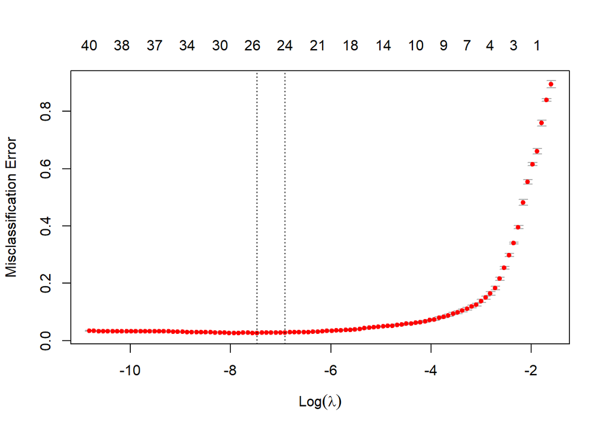

```r
plot(cross_validation)
```

```r
pre_tra = predict(cross_validation, newx=digit_tr_n,s=c("lambda.min"), type="class" )
# accuracy for train data
print(cross_validation)
```

```
##
## Call:  cv.glmnet(x = digit_tr_n, y = digit_tr$response, type.measure = "class",      nfolds = 10, family = "multinomial")
##
## Measure: Misclassification Error
##
##        Lambda Index Measure       SE Nonzero
## min 0.0005698    64 0.02616 0.002066      26
## 1se 0.0009957    58 0.02799 0.001953      24
```

```r
tab_tr=table(pre_tra[,1],digit_tr$response)
print("confusion matrix for the train data")
```

```
## [1] "confusion matrix for the train data"
```

```r
print(tab_tr)
```

```
##
##       0   1   2   3   4   5   6   7   8   9
##   0 373   0   0   0   0   0   0   0   1   1
##   1   0 378   0   0   1   1   2   0   4   4
##   2   0   1 378   0   0   0   0   0   0   0
##   3   0   0   0 383   0   1   0   1   0   1
##   4   1   1   0   0 383   0   2   0   2   1
##   5   1   0   0   3   0 371   0   0   1   1
##   6   1   0   1   0   2   0 373   0   0   0
##   7   0   2   0   1   0   0   0 386   0   0
##   8   0   5   0   0   0   0   0   0 372   2
##   9   0   2   1   2   1   3   0   0   0 372
```

```r
pre_te = predict(cross_validation, newx=digit_te_n,s=c("lambda.min"), type="class" )
# accuracy for train data
print(cross_validation)
```

```
##
## Call:  cv.glmnet(x = digit_tr_n, y = digit_tr$response, type.measure = "class",      nfolds = 10, family = "multinomial")
##
## Measure: Misclassification Error
##
##        Lambda Index Measure       SE Nonzero
## min 0.0005698    64 0.02616 0.002066      26
## 1se 0.0009957    58 0.02799 0.001953      24
```

```r
tab_te=table(pre_te[,1],digit_te$response)
print("confusion matrix for the train data")
```

```
## [1] "confusion matrix for the train data"
```

```r
print(tab_te)
```

```
##
##       0   1   2   3   4   5   6   7   8   9
##   0 176   0   0   0   0   0   0   0   0   0
##   1   0 172   2   0   1   0   1   0   8   1
##   2   0   0 174   4   0   1   0   0   0   0
##   3   0   0   0 172   0   0   0   0   0   1
##   4   0   0   0   0 177   0   2   2   1   1
##   5   2   0   0   2   0 176   0   5   3   4
##   6   0   0   1   0   0   2 177   0   0   0
##   7   0   0   0   1   1   0   0 166   0   0
##   8   0   6   0   2   2   0   1   0 158   3
##   9   0   4   0   2   0   3   0   6   4 170
```

```r
print(c("Train error",1-sum(diag(tab_tr)/sum(tab_tr))))
```

```
## [1] "Train error"       "0.014125032696835"
```

```r
print(c("Test error",1-sum(diag(tab_te)/sum(tab_te))))
```

```
## [1] "Test error"         "0.0439621591541458"
```